# EE0848 Machine Learning for SP

## Categorical Data

- Scikit-learn **does not** natively support categorical features in decision trees
- You need to encode categorical features (e.g., one-hot encoding, ordinal encoding)
- Some other libraries (e.g., LightGBM, CatBoost) handle categorical features directly

## Predicting Probabilities

- Fraction of class in leaf
- You can use `model.predict_proba()`
- Without pruning: Always 100% certain!
- Even with pruning might be too certain

# Ensemble Models

## Why Ensembles?

We saw that a single decision tree is **unstable** — small changes in data produce completely different trees.

**Key insight**: What if we trained *many* models and combined their predictions?

**Wisdom of Crowds**

- Individual models make different errors
- Combining predictions **averages out** those errors
- The ensemble is more stable and accurate than any single model

**Two main strategies:**

| Strategy | How it works |
| --- | --- |
| **Voting/Averaging** | Train diverse models, combine predictions |
| **Bagging** | Train same model type on different bootstrap samples |

## Hard vs. Soft Voting

**Hard voting** — each model casts a vote, majority wins:

| Model | Prediction |
| --- | --- |
| Logistic Regression | Class A |
| Decision Tree | Class B |
| SVM | Class A |
| **Ensemble** | **Class A** (2 vs 1) |

**Soft voting** — average the probability vectors, pick the highest:

| Model | P(A) | P(B) |
| --- | --- | --- |
| Logistic Regression | 0.60 | 0.40 |
| Decision Tree | 0.30 | 0.70 |
| SVM | 0.55 | 0.45 |
| **Average** | **0.48** | **0.52** |

Ensemble predicts **Class B** — different from hard voting!

Soft voting is generally better because it uses *confidence levels*, not just final predictions. But it requires well-calibrated probability estimates.

## VotingClassifier

```python
voting = VotingClassifier(
    [('logreg', LogisticRegression(C=100)),
     ('tree', DecisionTreeClassifier(
         max_depth=3, random_state=0))],
    voting='soft')
voting.fit(X_train, y_train)

lr, tree = voting.estimators_
tree.score(X_test, y_test)
lr.score(X_test, y_test)
voting.score(X_test, y_test)
```

Combining **different model types** works best when their errors are **uncorrelated** — each model captures different patterns in the data.

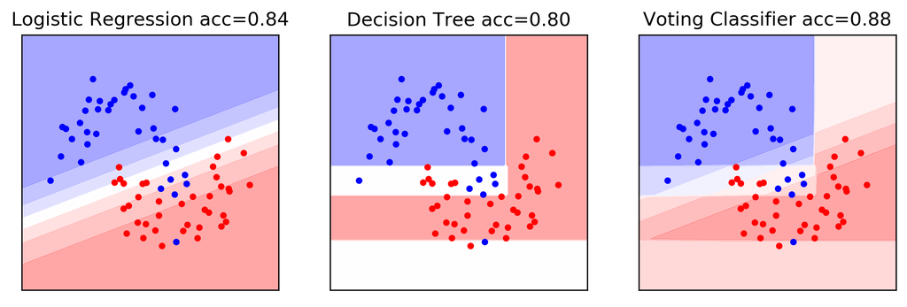

## Bagging (Bootstrap AGGregation)

What if we only have **one model type** (e.g., decision trees)?

We can create diversity by training on **different subsets** of data.

**Bootstrap sampling**: draw $n$ samples **with replacement** from $n$ training points

- Some points appear multiple times
- ~63.2% of unique points appear in each sample
- ~36.8% are left out (the “out-of-bag” samples)

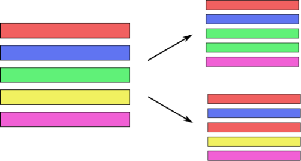

Each bootstrap sample has the same size as the original dataset, but with different compositions due to replacement.

`BaggingClassifier`, `BaggingRegressor`

## Bias-Variance Decomposition

For any model, the expected prediction error can be decomposed:

$$\text{Error} = \text{Bias}^2 + \text{Variance} + \text{Irreducible Noise}$$

| Component | Meaning |
| --- | --- |
| **Bias** | Systematic error — model consistently misses the target |
| **Variance** | Sensitivity to training data — predictions change a lot across datasets |
| **Noise** | Inherent randomness in the data — cannot be reduced |

**Decision trees** → low bias, **high variance**

**Linear models** → potentially high bias, **low variance**

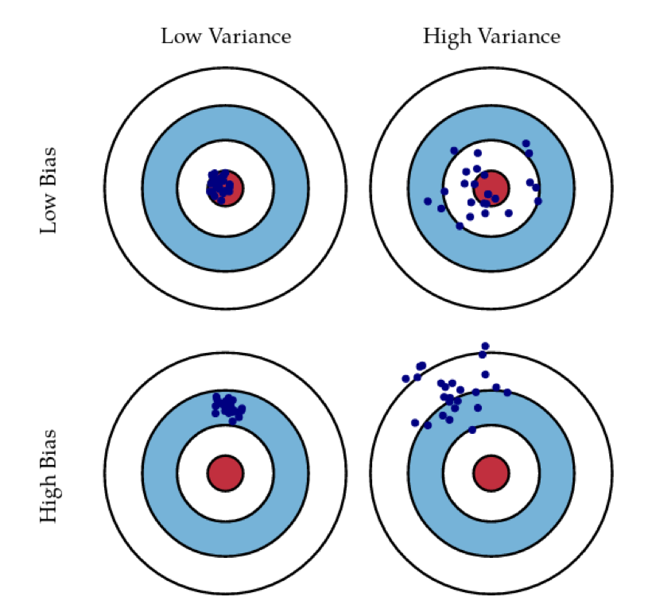

*http://scott.fortmann-roe.com/docs/BiasVariance.html*

## Bagging: Bias and Variance

- Bagging **reduces variance** without increasing bias
- Individual trees are high-variance, low-bias → bagging is a natural fit
- Generalization depends on **strength** of individual classifiers and (inversely) on their **correlation**
- Uncorrelating them might help, even at the expense of some individual strength

Bagging only helps high-variance models. Bagging a linear regression gives essentially the same result — low-variance models don’t benefit from averaging.

Can we reduce correlation even further? → **Random Forests**

# Random Forests

## Random Forests

We saw that a single tree is **unstable** — small data changes produce completely different trees. Random Forests fix this by averaging many randomized trees.

- **Classification**: Majority vote of all individual tree predictions
- If trees output reliable probabilities → average probability vectors and choose the class with highest average probability
- **Regression**: Mean value of all individual tree predictions

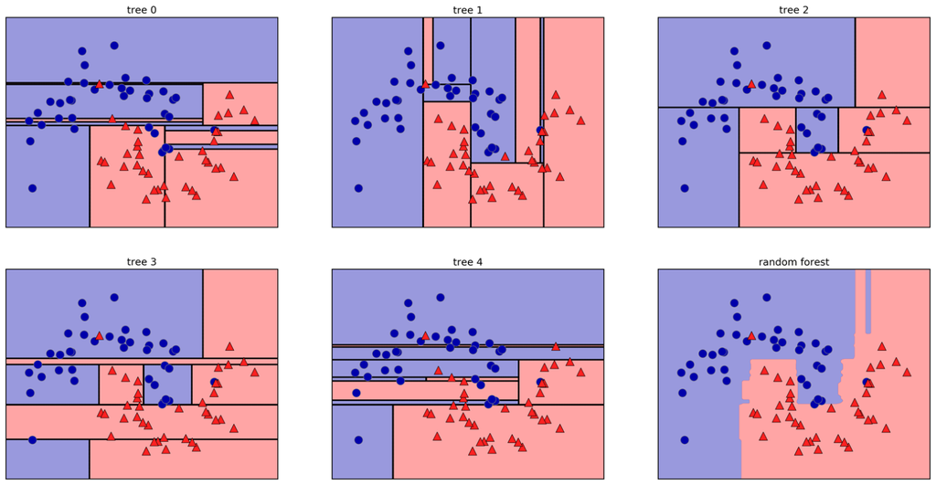

Each tree sees different data and features → different errors → averaging **cancels out** individual mistakes.

## Randomize in Two Ways

**For each tree:**

- Pick **bootstrap sample** of data (sample with replacement)

**For each split:**

- Pick **random subset of features** (not all features considered)

More trees are always better!

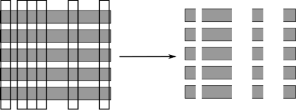

Left: full feature matrix. Right: each tree gets a bootstrap sample of rows and a random subset of columns.

Both sources of randomness reduce **correlation** between trees — the key to making the ensemble work.

## Tuning Random Forests

Key hyperparameters:

- `n_estimators` — number of trees (more is better, but slower)
- `max_features` — number of features to consider at each split
  - Classification default: `sqrt(n_features)`
  - Regression default: `n_features`
- `max_depth`, `min_samples_split`, etc. (same as single trees)
- `n_jobs=-1` to use all CPU cores

## Warm-Starts

- Having more trees is always better for performance
- Adding more trees and training from scratch takes time
- In scikit-learn, **Warm-Starts** iteratively add more trees to the forest
- You can stop whenever you think it’s good enough
- The `fit` method will keep all previous trees and add more

```python
train_scores = []
test_scores = []

rf = RandomForestClassifier(warm_start=True)
estimator_range = range(1, 100, 5)
for n_estimators in estimator_range:
    rf.n_estimators = n_estimators
    rf.fit(X_train, y_train)
    train_scores.append(rf.score(X_train, y_train))
    test_scores.append(rf.score(X_test, y_test))
```

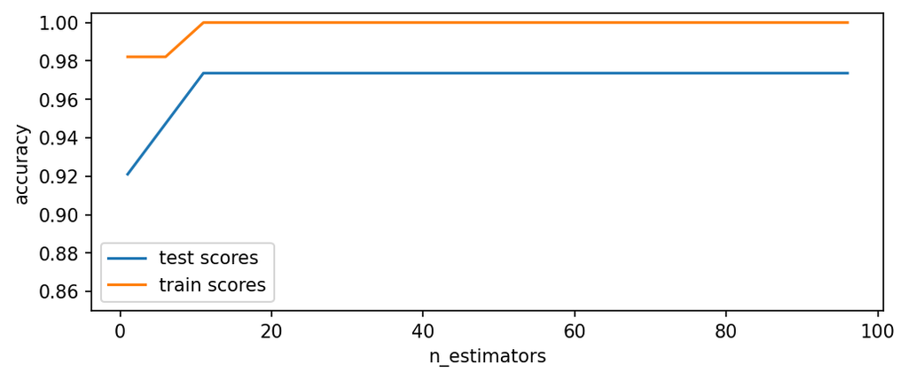

## Variable Importance

```python
X_train, X_test, y_train, y_test = train_test_split(
    iris.data, iris.target, stratify=iris.target, random_state=1)
rf = RandomForestClassifier().fit(X_train, y_train)
rf.feature_importances_
```

```
array([ 0.126,  0.033,  0.445,  0.396])
```

```python
plt.barh(range(4), rf.feature_importances_)
plt.yticks(range(4), iris.feature_names);
```

Compare with a single tree: `[0.0, 0.0, 0.414, 0.586]` — sepal features got **zero** importance. RF distributes importance more evenly because different trees use different features.

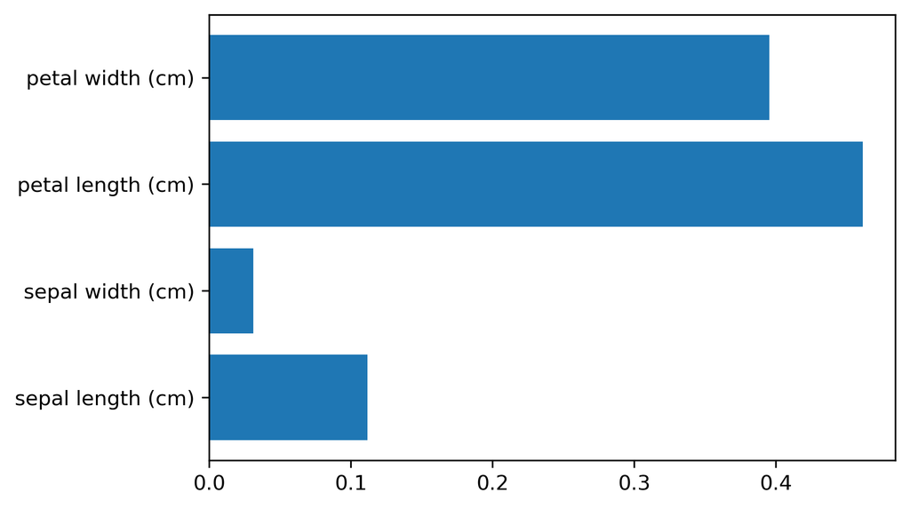

## Summary

- **Decision Trees**: Powerful, interpretable, non-parametric models that split on feature thresholds
- **Pruning**: Control tree complexity via `max_depth`, `max_leaf_nodes`, etc.
- **Ensemble Methods**: Combine multiple models for better performance
- **Random Forests**: Bagging + random feature selection → reduced variance
- **Key trade-offs**: Bias vs. variance, interpretability vs. performance